# Socio-Economic Indicators

Gonzalo Garcia

25/01/2021

# Exercise 1

## Q1. What is the level of inequality in this country? Use the different inequality measures presented in the course.

For answering this question we have a data base with the following information:

- IDidN: This is the individuals’ identification number.
- Sample_Weight: This is the sampling weight.
- Sex: Denotes individuals’ sex. 1=Men and 2=Women.
- HHidN: This is the household identification number.
- Hhtype: This is the household type. There are 6+1 kinds of households. 1=Unipersonal households, 2=Households “without family relationships”, 3=Couples without children, 4=Couples with children, 5=Single fathers, 6= Single mothers, 11=Other.
- Income: This is the income of the corresponding individual.

By using the package `dineq` and taking into accout the sample weight of each row, we can calculate the following 3 indeces for the whole sample:

### Gini Index (relative)

$$G(x) = \frac{\sum_{i=1}^{i=n} \sum_{j=1}^{j=n} |x_i - x_j | }{2 n^2 \mu}$$

```
## [1] 0.3310454
```

### Theil Index

$$T(x) = \frac{1}{n} \sum_{i=1}^{i=n} \frac{x_i}{\mu} log(\frac{x_i}{\mu})$$

```
## [1] 0.1709477
```

### Coefficient of Variability Index

$$CV(x) = \frac{\frac{1}{n} \sum_{i=1}^{i=n} (x_i - \mu)^2}{\mu}$$

```
## # A tibble: 1 x 1
##   cv_sample
##       <dbl>
## 1     0.631
```

We can see that the indeces are not comparable between them since they are in different scales. But what we can do is calculating these indeces for each subgroup (Household Type) and rank each subgroup to compare between them, for the different indices.

## 2. What is the level of inequality for the different household types? Use the different inequality measures presented in the course. Are the different household types ranked consistently when using the different inequality indices?

When we replicate the same procedure but applied to each different type of household, we get the following table:

| house_cat | gini_group | theil_group | group_cv | cv_rank | theil_rank | gini_rank |
| --- | --- | --- | --- | --- | --- | --- |
| 11 - Other | 0.2446217 | 0.0976116 | 0.4656085 | 1 | 1 | 1 |
| 02 - Households without family relationships | 0.3025726 | 0.1449416 | 0.5664053 | 2 | 2 | 2 |
| 06 - Single mothers | 0.3261104 | 0.1683918 | 0.6194918 | 3 | 3 | 3 |
| 04 - Couples with children | 0.3298600 | 0.1696706 | 0.6231355 | 4 | 4 | 4 |
| 03 - Couples without children | 0.3360315 | 0.1757185 | 0.6450196 | 5 | 6 | 5 |
| 01 - Unipersonal households | 0.3433399 | 0.1755075 | 0.6704253 | 6 | 5 | 6 |
| 05 - Single fathers | 0.3528134 | 0.2040281 | 0.6815433 | 7 | 7 | 7 |

To understand what we are refering when using the word “within”, let’s go the next question.

## 3. Decompose total inequality in inequality within groups + inequality between groups (use the (decomposable) inequality measure you prefer). What is the contribution of each component to overall inequality?

We can divide the inequality of a sample in 2 parts:

- Within $I_W$: inequality from the subgroup
- Between $I_B$: inequality between the different groups

For the case of the Theil index, we know that it is not only decomposable, but it additively decomposable, which means that both parts of the decomposition sum up to the total.

The formula for decomposing this particular index is:

$$T(x) = T_B (x) + T_I (x)$$
$$T(x) = \sum_{g=1}^{G} p_g \frac{\mu_g}{\mu} ln(\frac{\mu_g}{\mu} + \sum_{g=1}^{G} p_g \frac{\mu_g}{\mu} T_g)$$

Where $p_g$, $\mu_g$ and $T_g$ are the population share, arithmetic mean and Theil index of subgroup g, respectively.

Applying the formula to our data set we get the following result:

```
## # A tibble: 1 x 2
##   theil_w theil_b
##     <dbl>   <dbl>
## 1   0.169 0.00241
```

This means that 98.6% of the inequality represented by the Theil index corresponds to the inequality within each group in this data set. The different groups are not that different between them, but most of the inequality comes from the distribution of Income inside each type of household.

As we can imagine, that a group is more or less equal tells nothing about the potential living conditions of that group. In point 2 we saw that “Single Mothers” is the 3rd most equal category but the literature also tells us that poverty is more spread into that kind of households (Lu et al. 2020), (Stack and Meredith 2018). That is why in the next section we will revise poverty measures for our data set.

## 4. Let’s define the poverty threshold as 60% of the median (the standard definition used in the EU). What is the level of poverty in that society according to FGT0, FGT1, and FGT2?

We will calculate the poverty line *z* as the 60% of the median of Income in this data set (taking into account the sample weight of each individual):

Being of:

```
## # A tibble: 1 x 1
##   poverty_line
##          <dbl>
## 1        7816.
```

If we define the FGT (Foster-Greer-Thorbecke) poverty measures (Foster, Greer, and Thorbecke 1984) as:

$$FGT_\alpha = \frac{1}{n} \sum_{i=1}^{i=n} \max{((\frac{z-x_i}{z})^\alpha, 0)}$$
where $z$ is the poverty line measured before.

We are interested in calculating the measures when $\alpha$ takes the values: 0, 1, 2.

We get the following results:

```
## # A tibble: 1 x 3
##   fgt_0  fgt_1  fgt_2
##   <dbl>  <dbl>  <dbl>
## 1 0.208 0.0825 0.0530
```

As we can see, by modifying the value of $\alpha$ we weight more heavily to those individuals that are too far away from the `$7815` poverty line. In the case of $FGT_0$, if the individual is just 1 dollar below the line is already consider as “poor”.

Now we are ready to complement the equality measures we calculated for each kind of household with a poverty measure.

## 5. What is the level of poverty (according to FGT0, FGT1, and FGT2) for the different household types? Are the different household types ranked consistently when using the different poverty indices?

By applying the FGT’s formula for each household group and ranking each type for each index we get:

| house_cat | fgt_0i | fgt_1i | fgt_2i | fgt_0_rank | fgt_1_rank | fgt_2_rank |
| --- | --- | --- | --- | --- | --- | --- |
| 03 - Couples without children | 0.1813138 | 0.0622326 | 0.0366268 | 1 | 1 | 1 |
| 11 - Other | 0.1994297 | 0.0706694 | 0.0395531 | 4 | 2 | 2 |
| 02 - Households without family relationships | 0.1853349 | 0.0783251 | 0.0529119 | 2 | 3 | 3 |
| 04 - Couples with children | 0.2038596 | 0.0850548 | 0.0558285 | 5 | 4 | 4 |
| 06 - Single mothers | 0.2779032 | 0.1012001 | 0.0595610 | 7 | 6 | 5 |
| 01 - Unipersonal households | 0.2569687 | 0.0965250 | 0.0651349 | 6 | 5 | 6 |
| 05 - Single fathers | 0.1980283 | 0.1136735 | 0.0861925 | 3 | 7 | 7 |

Now “Single Mothers” is not that well placed anymore. It is also interesting to see the difference we get in the ranking of households once we change the $\alpha$ of the formula. Even though “Couples without children” perform better no matter the index, “Single Fathers” go to the bottom of the ranking when weighting how much distance from the poverty line each individual is. This matches with the ranking in the inequality measure: there is so much inequality in “Single Fathers” that a group of them is very poor and there is another group that is not poor at all.

So I took the liberty of plotting the income distribution for this particular group and compare them to the “Couples without children” category:

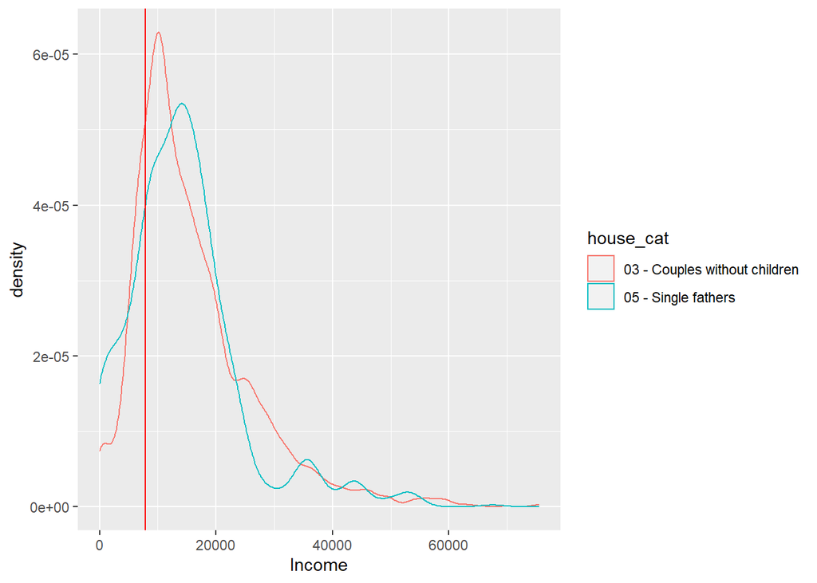

The red vertical line represents the poverty line calculated before. It is clear that the distribution of “Single Fathers” is closer to the `$0` axis, but it is also clear that those “bumps” we see in the distribution are clusters of income which “misguide” the poverty measure when we do not take into account the distance to the red line for each individual.

# References

Foster, James, Joel Greer, and Erik Thorbecke. 1984. “A Class of Decomposable Poverty Measures.” *Econometrica: Journal of the Econometric Society*, 761–66.

Lu, Yuan-Chiao, Regine Walker, Patrick Richard, and Mustafa Younis. 2020. “Inequalities in Poverty and Income Between Single Mothers and Fathers.” *International Journal of Environmental Research and Public Health* 17 (1): 135.

Stack, Rebecca Jayne, and Alex Meredith. 2018. “The Impact of Financial Hardship on Single Parents: An Exploration of the Journey from Social Distress to Seeking Help.” *Journal of Family and Economic Issues* 39 (2): 233–42.